# Modeling in Regression Lab: Module 1

Author

Yashwanth Krishna

**Throughout the course, we will be using the [Board Game Geek dataset from Tidy Tuesday](https://github.com/rfordatascience/tidytuesday/tree/master/data/2022/2022-01-25).**

$$\phi(Z)={1-1/d} \sum^d_{i=1} s^{2}_{f_i}/ k.d(1-k/d)$$
$$\phi(W)={1-1/d} \sum^d_{i=1} \sigma^{2}_{w_i}/ |\mu_{w_i}|$$
$$F=1/|X'| \sum_{x'\epsilon X'} |Y(x)-Y(x')|/Y(x)$$

```r
# do not edit this block
library(tidyverse)

ratings <-
  read_csv('https://raw.githubusercontent.com/rfordatascience/tidytuesday/master/data/2022/2022-01-25/ratings.csv') %>%
  select(-num)

details <-
  read_csv('https://raw.githubusercontent.com/rfordatascience/tidytuesday/master/data/2022/2022-01-25/details.csv') %>%
  select(-num)

bgg <- full_join(ratings, details, by = "id") %>%
  drop_na(average, yearpublished, minage)
```

Tuesday, August 20: Introduction to R and Quarto

**1. How many total observations (rows) are there in the dataset?**

There are 21631 observations(rows) are there in the dataset(bgg).

**2. List the first 5 variables (columns) in the dataset.**

id, name, year, rank, average, these are the 5 variables(columns) in the dataset(bgg).

Thursday, August 22: Review of Statistical Modeling

**3. We will be working with the average user rating (*average*), year the game was published (*yearpublished*), and the minimum age suggested to play the game (*minage*), and the. Explore each of these variables: provide the mean with standard deviation, median with IQR, and a histogram to determine the shape of the distribution.**

```r
bgg %>%
  summarize(mean_average=round(mean(average, na.rm =TRUE),2),
            sd_average=round(sd(average, na.rm =TRUE),2),
            median_average=round(median(average, na.rm = TRUE),2),
            IQR_average=round(IQR(average, na.rm =TRUE),2))
```

```
# A tibble: 1 × 4
  mean_average sd_average median_average IQR_average
         <dbl>      <dbl>          <dbl>       <dbl>
1         6.42       0.93           6.45        1.21
```

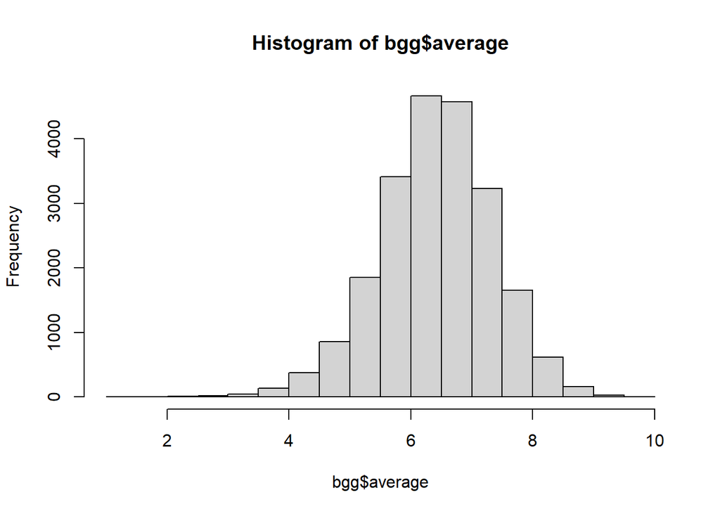

```r
hist(bgg$average)
```

```r
bgg%>%
  summarize(mean_yearpublished=round(mean(yearpublished, na.rm =TRUE),2),
            sd_yearpublished=round(sd(yearpublished, na.rm =TRUE),2),
            median_yearpublished=round(median(yearpublished, na.rm = TRUE),2),
            IQR_yearpublished=round(IQR(yearpublished, na.rm =TRUE),2))
```

```
# A tibble: 1 × 4
  mean_yearpublished sd_yearpublished median_yearpublished IQR_yearpublished
               <dbl>            <dbl>                <dbl>             <dbl>
1              1986.             210.                 2011                16
```

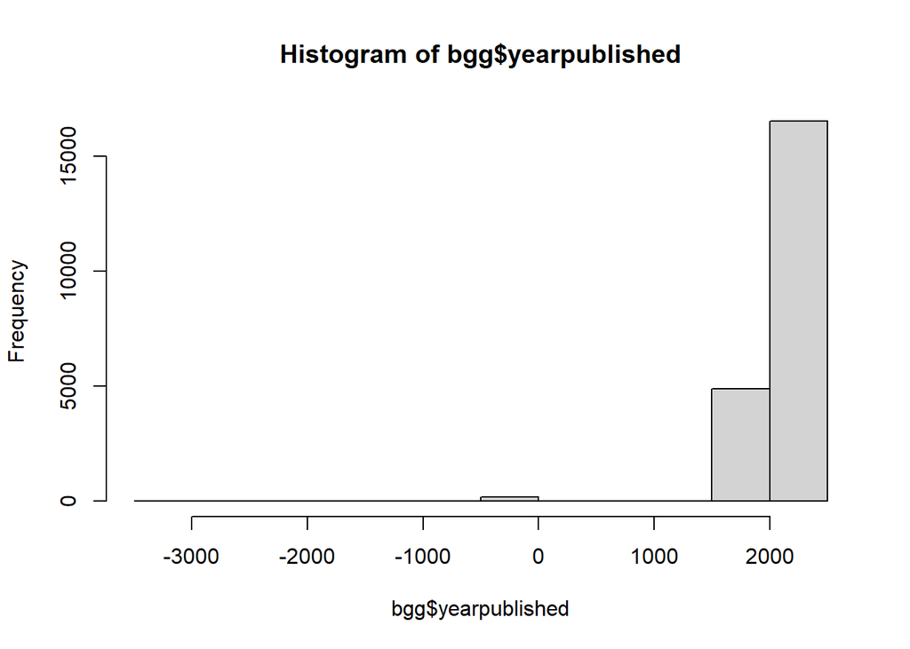

```r
hist(bgg$yearpublished)
```

```r
bgg%>%
  summarize(mean_minage=round(mean(minage, na.rm =TRUE),2),
            sd_minage=round(sd(minage, na.rm =TRUE),2),
            median_minage=round(median(minage, na.rm = TRUE),2),
            IQR_minage=round(IQR(minage, na.rm =TRUE),2))
```

```
# A tibble: 1 × 4
  mean_minage sd_minage median_minage IQR_minage
        <dbl>     <dbl>         <dbl>      <dbl>
1        9.61      3.64            10          4
```

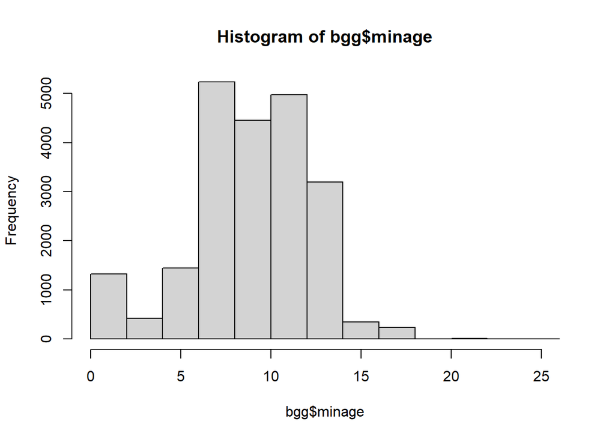

```r
hist(bgg$minage)
```

**4. Model the average user rating (*average*) as a function of year published (*yearpublished*) and minimum age (*minage*). Remember to state (typeset) the resulting model.**

```r
m1 <- glm(average ~ yearpublished + minage,
          data = bgg,
          family = "gaussian")
summary(m1)
```

```
Call:
glm(formula = average ~ yearpublished + minage, family = "gaussian",
    data = bgg)

Coefficients:
               Estimate Std. Error t value Pr(>|t|)
(Intercept)   5.4187579  0.0598715  90.507   <2e-16 ***
yearpublished 0.0002737  0.0000296   9.247   <2e-16 ***
minage        0.0473229  0.0017078  27.709   <2e-16 ***
---
Signif. codes:  0 '***' 0.001 '**' 0.01 '*' 0.05 '.' 0.1 ' ' 1

(Dispersion parameter for gaussian family taken to be 0.8289289)

    Null deviance: 18681  on 21630  degrees of freedom
Residual deviance: 17928  on 21628  degrees of freedom
AIC: 57333

Number of Fisher Scoring iterations: 2
```

```r
coefficients(m1)
```

```
  (Intercept) yearpublished        minage
 5.4187578990  0.0002737295  0.0473228838
```

Thus, the resulting model is
$$\hat{y}=5.4187+0.0002x_1+0.0473x_2$$
where,

$y$ is the average,

$x_1$ is the yearpublished, and

$x_2$ is the minage.

```r
full <- glm(average ~ yearpublished + minage, data = bgg, family = "gaussian")
reduced <- glm(average ~ 1, data = bgg, family = "gaussian")
anova(reduced, full, test = "F")
```

```
Analysis of Deviance Table

Model 1: average ~ 1
Model 2: average ~ yearpublished + minage
  Resid. Df Resid. Dev Df Deviance      F    Pr(>F)
1     21630      18681
2     21628      17928  2   753.37 454.42 < 2.2e-16 ***
---
Signif. codes:  0 '***' 0.001 '**' 0.01 '*' 0.05 '.' 0.1 ' ' 1
```

**5. Let’s scale the predictors – note that in your model, you should see very small coefficients, which does not make for a meaningful interpretation. Perform the appropriate data management steps to scale the year published by 25 years and to scale the minimum age by 5 years.**

```r
bgg$yearpublished_scaled <- bgg$yearpublished/25
bgg$minage_scaled <- bgg$minage/5
```

**6. Reconstruct your model from Q4 using the scaled predictors from Q5. Remember to state (typeset) the resulting model.**

```r
m2 <- glm(average ~ yearpublished_scaled + minage_scaled,
          data = bgg,
          family = "gaussian")
summary(m2)
```

```
Call:
glm(formula = average ~ yearpublished_scaled + minage_scaled,
    family = "gaussian", data = bgg)

Coefficients:
                     Estimate Std. Error t value Pr(>|t|)
(Intercept)          5.418758   0.059872  90.507   <2e-16 ***
yearpublished_scaled 0.006843   0.000740   9.247   <2e-16 ***
minage_scaled        0.236614   0.008539  27.709   <2e-16 ***
---
Signif. codes:  0 '***' 0.001 '**' 0.01 '*' 0.05 '.' 0.1 ' ' 1

(Dispersion parameter for gaussian family taken to be 0.8289289)

    Null deviance: 18681  on 21630  degrees of freedom
Residual deviance: 17928  on 21628  degrees of freedom
AIC: 57333

Number of Fisher Scoring iterations: 2
```

```r
coefficients(m2)
```

```
         (Intercept) yearpublished_scaled        minage_scaled
         5.418757899          0.006843236          0.236614419
```

Thus, the resulting model is
$$\hat{y}=5.418+0.006x_1+0.236x_2$$
where,

$y$ is the average,

$x_1$ is the yearpublished_scaled, and

$x_2$ is the minage_scaled.

```r
full_scaled <- glm(average ~ yearpublished_scaled + minage_scaled, data = bgg, family = "gaussian")
reduced_scaled <- glm(average ~ 1, data = bgg, family = "gaussian")
anova(reduced_scaled, full_scaled, test = "F")
```

```
Analysis of Deviance Table

Model 1: average ~ 1
Model 2: average ~ yearpublished_scaled + minage_scaled
  Resid. Df Resid. Dev Df Deviance      F    Pr(>F)
1     21630      18681
2     21628      17928  2   753.37 454.42 < 2.2e-16 ***
---
Signif. codes:  0 '***' 0.001 '**' 0.01 '*' 0.05 '.' 0.1 ' ' 1
```

**7. Let’s compare the model results from Q4 and Q6.**

**8. Is the model in Q6 significant at the** $\alpha$ = 0.05 level? You must typeset the results of your hypothesis test.

```r
full_scaled <- glm(average ~ yearpublished_scaled + minage_scaled, data = bgg, family = "gaussian")
reduced_scaled <- glm(average ~ 1, data = bgg, family = "gaussian")
anova(reduced_scaled, full_scaled, test = "F")
```

```
Analysis of Deviance Table

Model 1: average ~ 1
Model 2: average ~ yearpublished_scaled + minage_scaled
  Resid. Df Resid. Dev Df Deviance      F    Pr(>F)
1     21630      18681
2     21628      17928  2   753.37 454.42 < 2.2e-16 ***
---
Signif. codes:  0 '***' 0.001 '**' 0.01 '*' 0.05 '.' 0.1 ' ' 1
```

```r
summary(m2)
```

```
Call:
glm(formula = average ~ yearpublished_scaled + minage_scaled,
    family = "gaussian", data = bgg)

Coefficients:
                     Estimate Std. Error t value Pr(>|t|)
(Intercept)          5.418758   0.059872  90.507   <2e-16 ***
yearpublished_scaled 0.006843   0.000740   9.247   <2e-16 ***
minage_scaled        0.236614   0.008539  27.709   <2e-16 ***
---
Signif. codes:  0 '***' 0.001 '**' 0.01 '*' 0.05 '.' 0.1 ' ' 1

(Dispersion parameter for gaussian family taken to be 0.8289289)

    Null deviance: 18681  on 21630  degrees of freedom
Residual deviance: 17928  on 21628  degrees of freedom
AIC: 57333

Number of Fisher Scoring iterations: 2
```

- **Hypotheses**
  - $H_0$: model in Q6 is not significant.
  - $H_1$: model in Q6 is significant.
- **Test Statistic and** $p$-Value
  - $F_{0}=454.42$
  - $p<0.001$
- **Rejection Region**
  - Reject $H_0$ if $p < \alpha$; $\alpha =0.05$.
- **Conclusion and Interpretation**
  - Reject $H_0$.
  - As the p<0.05, There is sufficient evidence to suggest that the model is significant .

**9. Are there any significant predictors of average rating at the** $\alpha$ = 0.05 level? You must typeset the results of your hypothesis tests.

```r
summary(m2)
```

```
Call:
glm(formula = average ~ yearpublished_scaled + minage_scaled,
    family = "gaussian", data = bgg)

Coefficients:
                     Estimate Std. Error t value Pr(>|t|)
(Intercept)          5.418758   0.059872  90.507   <2e-16 ***
yearpublished_scaled 0.006843   0.000740   9.247   <2e-16 ***
minage_scaled        0.236614   0.008539  27.709   <2e-16 ***
---
Signif. codes:  0 '***' 0.001 '**' 0.01 '*' 0.05 '.' 0.1 ' ' 1

(Dispersion parameter for gaussian family taken to be 0.8289289)

    Null deviance: 18681  on 21630  degrees of freedom
Residual deviance: 17928  on 21628  degrees of freedom
AIC: 57333

Number of Fisher Scoring iterations: 2
```

*Test for publishing year*

- **Hypotheses**
  - $H_0$: It is not a significant predictor of average
  - $H_1$: It is a significant predictor of average
- **Test Statistic and** $p$-Value
- t-value=9.247
- p-value<2e-16
- **Rejection Region**
  - Reject $H_0$ if $p < \alpha$; $\alpha =0.05$.
- **Conclusion and Interpretation**
  - Reject $H_0$.
  - As the p-value < $\alpha$There is sufficient evidence to suggest that yearpublished is a significant predictor of average.

*Test for minimum age*

- **Hypotheses**
  - $H_0$: It is not a significant predictor of average
  - $H_1$: It is a significant predictor of average
- **Test Statistic and** $p$-Value
  - t-value=27.709
  - p-value <2e-16
- **Rejection Region**
  - Reject $H_0$ if $p < \alpha$; $\alpha =0.05$.
- **Conclusion and Interpretation**
  - Reject $H_0$.
  - As the p-value < $\alpha$There is sufficient evidence to suggest that minage is a significant predictor of average.

Tuesday, August 27: Introduction of Categorical Predictors

**10. Let’s explore the player variables a little more.**

- **What are the possible responses in the minimum number of players?**

```r
head(bgg, n=5)
```

```
# A tibble: 5 × 32
     id name        year  rank average bayes_average users_rated url   thumbnail
  <dbl> <chr>      <dbl> <dbl>   <dbl>         <dbl>       <dbl> <chr> <chr>
1 30549 Pandemic    2008   106    7.59          7.49      108975 /boa… https://…
2   822 Carcasson…  2000   190    7.42          7.31      108738 /boa… https://…
3    13 Catan       1995   429    7.14          6.97      108024 /boa… https://…
4 68448 7 Wonders   2010    73    7.74          7.63       89982 /boa… https://…
5 36218 Dominion    2008   104    7.61          7.50       81561 /boa… https://…
# ℹ 23 more variables: primary <chr>, description <chr>, yearpublished <dbl>,
#   minplayers <dbl>, maxplayers <dbl>, playingtime <dbl>, minplaytime <dbl>,
#   maxplaytime <dbl>, minage <dbl>, boardgamecategory <chr>,
#   boardgamemechanic <chr>, boardgamefamily <chr>, boardgameexpansion <chr>,
#   boardgameimplementation <chr>, boardgamedesigner <chr>,
#   boardgameartist <chr>, boardgamepublisher <chr>, owned <dbl>,
#   trading <dbl>, wanting <dbl>, wishing <dbl>, yearpublished_scaled <dbl>, …
```

```r
bgg %>% count(minplayers)
```

```
# A tibble: 11 × 2
   minplayers     n
        <dbl> <int>
 1          0    44
 2          1  3675
 3          2 14834
 4          3  2462
 5          4   503
 6          5    59
 7          6    24
 8          7    11
 9          8    16
10          9     1
11         10     2
```

```r
library(fastDummies)
bgg <- bgg %>%
  dummy_cols(select_columns = c("minplayers"))

bgg %>%
  select(starts_with("minplayers")) %>%
  head(3)
```

```
# A tibble: 3 × 12
  minplayers minplayers_0 minplayers_1 minplayers_2 minplayers_3 minplayers_4
       <dbl>        <int>        <int>        <int>        <int>        <int>
1          2            0            0            1            0            0
2          2            0            0            1            0            0
3          3            0            0            0            1            0
# ℹ 6 more variables: minplayers_5 <int>, minplayers_6 <int>,
#   minplayers_7 <int>, minplayers_8 <int>, minplayers_9 <int>,
#   minplayers_10 <int>
```

- **What are the possible responses in the maximum number of players?**

```r
head(bgg, n=5)
```

```
# A tibble: 5 × 43
     id name        year  rank average bayes_average users_rated url   thumbnail
  <dbl> <chr>      <dbl> <dbl>   <dbl>         <dbl>       <dbl> <chr> <chr>
1 30549 Pandemic    2008   106    7.59          7.49      108975 /boa… https://…
2   822 Carcasson…  2000   190    7.42          7.31      108738 /boa… https://…
3    13 Catan       1995   429    7.14          6.97      108024 /boa… https://…
4 68448 7 Wonders   2010    73    7.74          7.63       89982 /boa… https://…
5 36218 Dominion    2008   104    7.61          7.50       81561 /boa… https://…
# ℹ 34 more variables: primary <chr>, description <chr>, yearpublished <dbl>,
#   minplayers <dbl>, maxplayers <dbl>, playingtime <dbl>, minplaytime <dbl>,
#   maxplaytime <dbl>, minage <dbl>, boardgamecategory <chr>,
#   boardgamemechanic <chr>, boardgamefamily <chr>, boardgameexpansion <chr>,
#   boardgameimplementation <chr>, boardgamedesigner <chr>,
#   boardgameartist <chr>, boardgamepublisher <chr>, owned <dbl>,
#   trading <dbl>, wanting <dbl>, wishing <dbl>, yearpublished_scaled <dbl>, …
```

```r
bgg %>% count(maxplayers)
```

```
# A tibble: 52 × 2
   maxplayers     n
        <dbl> <int>
 1          0   164
 2          1   369
 3          2  4287
 4          3   279
 5          4  6810
 6          5  2987
 7          6  3969
 8          7   324
 9          8  1218
10          9    75
# ℹ 42 more rows
```

```r
library(fastDummies)
bgg <- bgg %>%
  dummy_cols(select_columns = c("maxplayers"))

bgg %>%
  select(starts_with("maxplayers")) %>%
  head(3)
```

```
# A tibble: 3 × 53
  maxplayers maxplayers_0 maxplayers_1 maxplayers_2 maxplayers_3 maxplayers_4
       <dbl>        <int>        <int>        <int>        <int>        <int>
1          4            0            0            0            0            1
2          5            0            0            0            0            0
3          4            0            0            0            0            1
# ℹ 47 more variables: maxplayers_5 <int>, maxplayers_6 <int>,
#   maxplayers_7 <int>, maxplayers_8 <int>, maxplayers_9 <int>,
#   maxplayers_10 <int>, maxplayers_11 <int>, maxplayers_12 <int>,
#   maxplayers_13 <int>, maxplayers_14 <int>, maxplayers_15 <int>,
#   maxplayers_16 <int>, maxplayers_17 <int>, maxplayers_18 <int>,
#   maxplayers_20 <int>, maxplayers_21 <int>, maxplayers_22 <int>,
#   maxplayers_24 <int>, maxplayers_25 <int>, maxplayers_26 <int>, …
```

**11. Let’s treat minimum and maximum number of players as categorical variables, however, they have too many categories for reasonable interpretation. Perform the appropriate data management steps to create the following variables:**

- **an indicator for games that require 2 players**
- **a character variable classifying games as follows:**
  - *minplayers*$\in$ {0, 1} $\to$ “1 - not interested”
  - *minplayers*$\in$ {2, 3} $\to$ “2 - can play with family”
  - *minplayers* **> 3** $\to$ “3 - can play with friends”

```r
library(fastDummies)
bgg <- bgg %>%
  mutate(games = ifelse(minplayers == 2, 1, 0)) %>%
  mutate(games_classification = case_when(
    minplayers %in% c(0,1) ~ "1 - not interested",
    minplayers %in% c(2, 3) ~ "2 - can play with family",
    minplayers > 3 ~ "3 - can play with friends"))

bgg %>%
  select(minplayers, games, games_classification) %>%
  head(n = 100)
```

```
# A tibble: 100 × 3
   minplayers games games_classification
        <dbl> <dbl> <chr>
 1          2     1 2 - can play with family
 2          2     1 2 - can play with family
 3          3     0 2 - can play with family
 4          2     1 2 - can play with family
 5          2     1 2 - can play with family
 6          2     1 2 - can play with family
 7          2     1 2 - can play with family
 8          1     0 1 - not interested
 9          2     1 2 - can play with family
10          1     0 1 - not interested
# ℹ 90 more rows
```

**12. Model the average user rating (*average*) as a function of games that require 2 players (variable from Q11) and scaled minimum age (variable from Q5). Remember to state (typeset) the resulting model.**

```r
m3 <- glm(average ~ games + minage_scaled,
          data = bgg,
          family = "gaussian")
summary(m3)
```

```
Call:
glm(formula = average ~ games + minage_scaled, family = "gaussian",
    data = bgg)

Coefficients:
               Estimate Std. Error t value Pr(>|t|)
(Intercept)    6.147772   0.020503  299.84   <2e-16 ***
games         -0.244432   0.013335  -18.33   <2e-16 ***
minage_scaled  0.227388   0.008502   26.75   <2e-16 ***
---
Signif. codes:  0 '***' 0.001 '**' 0.01 '*' 0.05 '.' 0.1 ' ' 1

(Dispersion parameter for gaussian family taken to be 0.8194753)

    Null deviance: 18681  on 21630  degrees of freedom
Residual deviance: 17724  on 21628  degrees of freedom
AIC: 57085

Number of Fisher Scoring iterations: 2
```

```r
coefficients(m3)
```

```
  (Intercept)         games minage_scaled
    6.1477721    -0.2444317     0.2273877
```

Thus, the resulting model is
$$\hat{y}=6.15-0.24x_1+0.23x_2$$
where,

$y$ is the average,

$x_1$ is the games, and

$x_2$ is the minage_scaled.

**13. Are there any significant predictors of average rating at the** $\alpha$ = 0.05 level? You must typeset the results of your hypothesis tests.

```r
car::Anova(m3, type = 3)
```

```
Analysis of Deviance Table (Type III tests)

Response: average
              LR Chisq Df Pr(>Chisq)
games           336.00  1  < 2.2e-16 ***
minage_scaled   715.34  1  < 2.2e-16 ***
---
Signif. codes:  0 '***' 0.001 '**' 0.01 '*' 0.05 '.' 0.1 ' ' 1
```

```r
summary(m3)
```

```
Call:
glm(formula = average ~ games + minage_scaled, family = "gaussian",
    data = bgg)

Coefficients:
               Estimate Std. Error t value Pr(>|t|)
(Intercept)    6.147772   0.020503  299.84   <2e-16 ***
games         -0.244432   0.013335  -18.33   <2e-16 ***
minage_scaled  0.227388   0.008502   26.75   <2e-16 ***
---
Signif. codes:  0 '***' 0.001 '**' 0.01 '*' 0.05 '.' 0.1 ' ' 1

(Dispersion parameter for gaussian family taken to be 0.8194753)

    Null deviance: 18681  on 21630  degrees of freedom
Residual deviance: 17724  on 21628  degrees of freedom
AIC: 57085

Number of Fisher Scoring iterations: 2
```

*Test for minimum of 2 players*

- **Hypotheses**
  - $H_0$: It is no significant predictor of average
  - $H_1$: It is a significant predictor of average
- **Test Statistic and** $p$-Value
  - $t_0$= -18.33
  - $p$<0.001
- **Rejection Region**
  - Reject $H_0$ if $p < \alpha$; $\alpha =0.05$.
- **Conclusion and Interpretation**
  - Reject $H_0$.
  - As the p-value< alpha, there is sufficient evidence to suggest that games with minimum of 2 players is a significant predictor of average.

*Test for minimum age*

- **Hypotheses**
  - $H_0$: It is not a significant predictor of average
  - $H_1$: It is a significant predictor of average
- **Test Statistic and** $p$-Value
  - $t_{0}$=26.75
  - $p$<0.001
- **Rejection Region**
  - Reject $H_0$ if $p < \alpha$; $\alpha =0.05$.
- **Conclusion and Interpretation**
  - Reject $H_0$.
  - As the p-value< alpha, there is sufficient evidence to suggest that minimum age is a significant predictor of average.

**14. Provide brief interpretations of the regression slopes.**

**15. Model the average user rating (*average*) as a function of games classification (variable from Q11) and scaled minimum age (variable from Q5). Remember to state (typeset) the resulting model.**

```r
m4 <- glm(average ~ games_classification + minage_scaled,
          data = bgg,
          family = "gaussian")
summary(m4)
```

```
Call:
glm(formula = average ~ games_classification + minage_scaled,
    family = "gaussian", data = bgg)

Coefficients:
                                               Estimate Std. Error t value
(Intercept)                                    6.451329   0.022160  291.12
games_classification2 - can play with family  -0.568412   0.016051  -35.41
games_classification3 - can play with friends -0.669860   0.038582  -17.36
minage_scaled                                  0.228633   0.008309   27.52
                                              Pr(>|t|)
(Intercept)                                     <2e-16 ***
games_classification2 - can play with family    <2e-16 ***
games_classification3 - can play with friends   <2e-16 ***
minage_scaled                                   <2e-16 ***
---
Signif. codes:  0 '***' 0.001 '**' 0.01 '*' 0.05 '.' 0.1 ' ' 1

(Dispersion parameter for gaussian family taken to be 0.7855127)

    Null deviance: 18681  on 21630  degrees of freedom
Residual deviance: 16988  on 21627  degrees of freedom
AIC: 56170

Number of Fisher Scoring iterations: 2
```

```r
coefficients(m4)
```

```
                                  (Intercept)
                                    6.4513286
 games_classification2 - can play with family
                                   -0.5684123
games_classification3 - can play with friends
                                   -0.6698599
                                minage_scaled
                                    0.2286325
```

Thus, the resulting model is
$$\hat{y}=6.45-0.57x_1-0.67x_2+0.23x_3$$
where,

$y$ is the average,

$x_1$ is the games for minplayers $\in${2,3}

$x_2$ is the games for minplayers >3, and

$x_3$ is the minage_scaled.

**16. Are there any significant predictors of average rating at the** $\alpha$ = 0.05 level? You must typeset the results of your hypothesis tests.

```r
car::Anova(m4, type = 3)
```

```
Analysis of Deviance Table (Type III tests)

Response: average
                     LR Chisq Df Pr(>Chisq)
games_classification  1286.64  2  < 2.2e-16 ***
minage_scaled          757.13  1  < 2.2e-16 ***
---
Signif. codes:  0 '***' 0.001 '**' 0.01 '*' 0.05 '.' 0.1 ' ' 1
```

```r
summary(m4)
```

```
Call:
glm(formula = average ~ games_classification + minage_scaled,
    family = "gaussian", data = bgg)

Coefficients:
                                               Estimate Std. Error t value
(Intercept)                                    6.451329   0.022160  291.12
games_classification2 - can play with family  -0.568412   0.016051  -35.41
games_classification3 - can play with friends -0.669860   0.038582  -17.36
minage_scaled                                  0.228633   0.008309   27.52
                                              Pr(>|t|)
(Intercept)                                     <2e-16 ***
games_classification2 - can play with family    <2e-16 ***
games_classification3 - can play with friends   <2e-16 ***
minage_scaled                                   <2e-16 ***
---
Signif. codes:  0 '***' 0.001 '**' 0.01 '*' 0.05 '.' 0.1 ' ' 1

(Dispersion parameter for gaussian family taken to be 0.7855127)

    Null deviance: 18681  on 21630  degrees of freedom
Residual deviance: 16988  on 21627  degrees of freedom
AIC: 56170

Number of Fisher Scoring iterations: 2
```

*Test for game classification*

```r
car::Anova(m4, type = 3)
```

```
Analysis of Deviance Table (Type III tests)

Response: average
                     LR Chisq Df Pr(>Chisq)
games_classification  1286.64  2  < 2.2e-16 ***
minage_scaled          757.13  1  < 2.2e-16 ***
---
Signif. codes:  0 '***' 0.001 '**' 0.01 '*' 0.05 '.' 0.1 ' ' 1
```

```r
summary(m4)
```

```
Call:
glm(formula = average ~ games_classification + minage_scaled,
    family = "gaussian", data = bgg)

Coefficients:
                                               Estimate Std. Error t value
(Intercept)                                    6.451329   0.022160  291.12
games_classification2 - can play with family  -0.568412   0.016051  -35.41
games_classification3 - can play with friends -0.669860   0.038582  -17.36
minage_scaled                                  0.228633   0.008309   27.52
                                              Pr(>|t|)
(Intercept)                                     <2e-16 ***
games_classification2 - can play with family    <2e-16 ***
games_classification3 - can play with friends   <2e-16 ***
minage_scaled                                   <2e-16 ***
---
Signif. codes:  0 '***' 0.001 '**' 0.01 '*' 0.05 '.' 0.1 ' ' 1

(Dispersion parameter for gaussian family taken to be 0.7855127)

    Null deviance: 18681  on 21630  degrees of freedom
Residual deviance: 16988  on 21627  degrees of freedom
AIC: 56170

Number of Fisher Scoring iterations: 2
```

*Test for minimum age*

- **Hypotheses**
  - $H_0$: It is not a significant predictor of average
  - $H_1$: It is a significant predictor of average
- **Test Statistic and** $p$-Value
  - t-value=27.52
  - p<0.001
- **Rejection Region**
  - Reject $H_0$ if $p < \alpha$; $\alpha =0.05$.
- **Conclusion and Interpretation**
  - reject H0
  - as the p-value<alpha, there is enough evidence to suggest that the minimum age is a significant predictor for average.

**17. Provide brief interpretations of the regression slopes.**

Thursday, August 29: Introduction of Interaction Terms

**18. Model the average user rating (*average*) as a function of games classification (variable from Q11), scaled minimum age (variable from Q5), and the interaction between the two. Remember to state (typeset) the resulting model.**

**19. Is the interaction between game classification and the minimum age significant at the** $\alpha$ = 0.05 level? You must typeset the results of your hypothesis tests.

**20. Plug in the appropriate values to create separate models for each level of game categorization.**

**21. Provide brief interpretations for the models in Q20.**

**22. Construct a data visualization to allow us to visualize the regression lines found in Q20. Age (scaled by 5 years) should be on the** $x$-axis, average rating should be on the $y$-axis, and lines should be shown for the models in Q20.

Tuesday, September 10: Assumptions and Diagnostics of Linear Regression

**23. State the assumptions we assess for linear models under the normal distribution.**

**24. Graphically assess the assumptions of the linear model.**

**25. How many potential outliers exist?**

**26. How many influential/leverage points exist?**

**27. Determine if multicollinearity exists in this model.**

Tuesday, September 17: Gamma Regression

**28. Using gamma regression, model the average user rating (*average*) as a function of games classification (variable from Q11), scaled minimum age (variable from Q5), and the interaction between the two. Remember to state (typeset) the resulting model.**

**29. Is the interaction between game classification and the minimum age significant at the** $\alpha$ = 0.05 level? You must typeset the results of your hypothesis tests.

**30. Plug in the appropriate values to create separate models for each level of game categorization.**

**31. Provide brief interpretations for the slopes in Q30.**

**32. Construct a data visualization to allow us to visualize the regression lines found in Q30. Age (scaled by 5 years) should be on the** $x$-axis, average rating should be on the $y$-axis, and lines should be shown for the models in Q30.